# CSP571_Project_Experimentation for Pennsylvania conventional home loans for 2014

2/17/2020

## Global setup like working directory, data directory etc should happen here.

```r
# Please change the working directory as needed.
working_dir <- "D:/illinois/csp571/csp-571-02-final-project"
setwd(working_dir)
```

```
The working directory was changed to D:/illinois/csp571/csp-571-02-final-project inside a notebook chunk. The working directory will be reset when the chunk is finished running. Use the knitr root.dir option in the setup chunk to change the working directory for notebook chunks.
```

```r
data_dir <- "D:/data/HMDA"
```

## Install required packages.

```r
# https://stackoverflow.com/questions/4090169/elegant-way-to-check-for-missing-packages-and-install-them
list_of_packages <- c("mlbench", "corrplot", "rvest", "tidyr", "stringr", "dplyr", "lubridate", "data.table", "mice", "scales", "naniar", "rpart", "rpart.plot", "caret")
new.packages <- list_of_packages[!(list_of_packages %in% installed.packages()[,"Package"])]

if (length(new.packages)) {
  print("Installing packages\n")
  install.packages(new.packages())
}

library(corrplot)
library(ggplot2)
library(tidyr)
library(stringr)
library(dplyr)
library(data.table)
library(mice)
library(rstudioapi)
library(naniar)

source(paste(dirname(dirname(rstudioapi::getActiveDocumentContext()$path)), "utils/utils.r", sep="/"))
```

## Load data file.

```r
hmda_data_pa <- fread(paste(data_dir, "/2014/hmda_2014_pa_all-records_labels.csv", sep = ""))
```

```
|--------------------------------------------------|
|==================================================|
|--------------------------------------------------|
|==================================================|
```

## Data analysis section 1. Print column names and first 10 rows of dataset.

```r
hmda_data_pa_df <- as.data.frame(hmda_data_pa)

# Filter to include conventional loans only.
hmda_data_pa_df <- hmda_data_pa_df[hmda_data_pa_df$loan_type == "1", ]

colnames(hmda_data_pa_df)
```

```
 [1] "as_of_year"                     "respondent_id"
 [3] "agency_name"                    "agency_abbr"
 [5] "agency_code"                    "loan_type_name"
 [7] "loan_type"                      "property_type_name"
 [9] "property_type"                  "loan_purpose_name"
[11] "loan_purpose"                   "owner_occupancy_name"
[13] "owner_occupancy"                "loan_amount_000s"
[15] "preapproval_name"               "preapproval"
[17] "action_taken_name"              "action_taken"
[19] "msamd_name"                     "msamd"
[21] "state_name"                     "state_abbr"
[23] "state_code"                     "county_name"
[25] "county_code"                    "census_tract_number"
[27] "applicant_ethnicity_name"       "applicant_ethnicity"
[29] "co_applicant_ethnicity_name"    "co_applicant_ethnicity"
```

[output cut: 24 more lines]

```r
writeLines("")
```

```r
summary(hmda_data_pa_df)
```

```
   as_of_year   respondent_id      agency_name        agency_abbr
 Min.   :2014   Length:322785      Length:322785      Length:322785
 1st Qu.:2014   Class :character   Class :character   Class :character
 Median :2014   Mode  :character   Mode  :character   Mode  :character
 Mean   :2014
 3rd Qu.:2014
 Max.   :2014

  agency_code    loan_type_name       loan_type property_type_name
 Min.   :1.000   Length:322785      Min.   :1   Length:322785
 1st Qu.:5.000   Class :character   1st Qu.:1   Class :character
 Median :7.000   Mode  :character   Median :1   Mode  :character
 Mean   :6.348                      Mean   :1
 3rd Qu.:9.000                      3rd Qu.:1
 Max.   :9.000                      Max.   :1

 property_type   loan_purpose_name   loan_purpose   owner_occupancy_name
 Min.   :1.000   Length:322785      Min.   :1.000   Length:322785
 1st Qu.:1.000   Class :character   1st Qu.:1.000   Class :character
 Median :1.000   Mode  :character   Median :2.000   Mode  :character
 Mean   :1.032                      Mean   :2.075
 3rd Qu.:1.000                      3rd Qu.:3.000
 Max.   :3.000                      Max.   :3.000

 owner_occupancy loan_amount_000s  preapproval_name    preapproval
 Min.   :1.00    Min.   :    1.0   Length:322785      Min.   :1.000
 1st Qu.:1.00    1st Qu.:   60.0   Class :character   1st Qu.:3.000
 Median :1.00    Median :  120.0   Mode  :character   Median :3.000
 Mean   :1.12    Mean   :  168.2                      Mean   :2.879
 3rd Qu.:1.00    3rd Qu.:  206.0                      3rd Qu.:3.000
 Max.   :3.00    Max.   :99999.0                      Max.   :3.000

 action_taken_name   action_taken    msamd_name            msamd
 Length:322785      Min.   :1.000   Length:322785      Min.   :10900
 Class :character   1st Qu.:1.000   Class :character   1st Qu.:30140
 Mode  :character   Median :1.000   Mode  :character   Median :37964
                    Mean   :2.268                      Mean   :33728
                    3rd Qu.:3.000                      3rd Qu.:38300
                    Max.   :7.000                      Max.   :49660
                                                       NA's   :28898
```

[output cut: 129 more lines]

```
 Min.   : 12.10        Min.   :   7
 1st Qu.: 89.09        1st Qu.: 953
 Median :106.05        Median :1357
 Mean   :111.97        Mean   :1399
 3rd Qu.:127.01        3rd Qu.:1795
 Max.   :397.45        Max.   :3262
 NA's   :991           NA's   :963
 number_of_1_to_4_family_units application_date_indicator
 Min.   :   8                  Min.   :0.0000
 1st Qu.:1340                  1st Qu.:0.0000
 Median :1758                  Median :0.0000
 Mean   :1823                  Mean   :0.1732
 3rd Qu.:2289                  3rd Qu.:0.0000
 Max.   :4173                  Max.   :2.0000
 NA's   :945
```

```r
head(hmda_data_pa_df, 10)
```

|  | as_of_year | respondent_id | agency_name | agency_abbr | agency_code | loan_type_name | loan_type | property_type_name | property_type | loan_purpose_name | loan_purpose | owner_occupancy_name | owner_occupancy | loan_amount_000s | preapproval_name | preapproval | action_taken_name | action_taken | msamd_name | msamd | state_name | state_abbr | state_code | county_name | county_code | census_tract_number | applicant_ethnicity_name | applicant_ethnicity | co_applicant_ethnicity_name | … |
| --- | --- | --- | --- | --- | --- | --- | --- | --- | --- | --- | --- | --- | --- | --- | --- | --- | --- | --- | --- | --- | --- | --- | --- | --- | --- | --- | --- | --- | --- | --- |
| 2 | 2014 | 41-1795868 | Department of Housing and Urban Development | HUD | 7 | Conventional | 1 | One-to-four family dwelling (other than manufactured housing) | 1 | Refinancing | 3 | Owner-occupied as a principal dwelling | 1 | 81 | Not applicable | 3 | Application denied by financial institution | 3 |  | NA | Pennsylvania | PA | 42 | Lawrence County | 73 | 111.00 | Not Hispanic or Latino | 2 | No co-applicant | … |
| 3 | 2014 | 0000024891 | Office of the Comptroller of the Currency | OCC | 1 | Conventional | 1 | One-to-four family dwelling (other than manufactured housing) | 1 | Home purchase | 1 | Owner-occupied as a principal dwelling | 1 | 132 | Not applicable | 3 | Loan originated | 1 | York, Hanover - PA | 49620 | Pennsylvania | PA | 42 | York County | 133 | 207.10 | Not Hispanic or Latino | 2 | No co-applicant | … |
| 5 | 2014 | 62-1532940 | Department of Housing and Urban Development | HUD | 7 | Conventional | 1 | One-to-four family dwelling (other than manufactured housing) | 1 | Home purchase | 1 | Owner-occupied as a principal dwelling | 1 | 158 | Preapproval was not requested | 2 | Application denied by financial institution | 3 | Lancaster - PA | 29540 | Pennsylvania | PA | 42 | Lancaster County | 71 | 117.04 | Not Hispanic or Latino | 2 | No co-applicant | … |
| 8 | 2014 | 41-1795868 | Department of Housing and Urban Development | HUD | 7 | Conventional | 1 | One-to-four family dwelling (other than manufactured housing) | 1 | Refinancing | 3 | Owner-occupied as a principal dwelling | 1 | 236 | Not applicable | 3 | Application withdrawn by applicant | 4 | Montgomery County, Bucks County, Chester County - PA | 33874 | Pennsylvania | PA | 42 | Bucks County | 17 | 1016.03 | Not Hispanic or Latino | 2 | No co-applicant | … |
| 9 | 2014 | 0000057228 | Federal Deposit Insurance Corporation | FDIC | 3 | Conventional | 1 | One-to-four family dwelling (other than manufactured housing) | 1 | Refinancing | 3 | Owner-occupied as a principal dwelling | 1 | 53 | Not applicable | 3 | Loan originated | 1 | Allentown, Bethlehem, Easton - PA, NJ | 10900 | Pennsylvania | PA | 42 | Northampton County | 95 | 162.02 | Not Hispanic or Latino | 2 | No co-applicant | … |
| 10 | 2014 | 41-1795868 | Department of Housing and Urban Development | HUD | 7 | Conventional | 1 | One-to-four family dwelling (other than manufactured housing) | 1 | Home purchase | 1 | Not owner-occupied as a principal dwelling | 2 | 150 | Not applicable | 3 | Loan purchased by the institution | 6 | Montgomery County, Bucks County, Chester County - PA | 33874 | Pennsylvania | PA | 42 | Bucks County | 17 | 1055.10 | Not applicable | 4 | Not applicable | … |
| 11 | 2014 | 0000028178 | Federal Deposit Insurance Corporation | FDIC | 3 | Conventional | 1 | One-to-four family dwelling (other than manufactured housing) | 1 | Home purchase | 1 | Owner-occupied as a principal dwelling | 1 | 108 | Not applicable | 3 | Loan originated | 1 |  | NA | Pennsylvania | PA | 42 | Elk County | 47 | 9511.00 | Not Hispanic or Latino | 2 | No co-applicant | … |
| 12 | 2014 | 0000002099 | National Credit Union Administration | NCUA | 5 | Conventional | 1 | One-to-four family dwelling (other than manufactured housing) | 1 | Refinancing | 3 | Owner-occupied as a principal dwelling | 1 | 265 | Not applicable | 3 | Loan originated | 1 | Montgomery County, Bucks County, Chester County - PA | 33874 | Pennsylvania | PA | 42 | Chester County | 29 | 3044.05 | Not Hispanic or Latino | 2 | Not Hispanic or Latino | … |
| 13 | 2014 | 75-2921540 | Department of Housing and Urban Development | HUD | 7 | Conventional | 1 | One-to-four family dwelling (other than manufactured housing) | 1 | Refinancing | 3 | Owner-occupied as a principal dwelling | 1 | 196 | Not applicable | 3 | Application denied by financial institution | 3 |  | NA | Pennsylvania | PA | 42 | Schuylkill County | 107 | 38.00 | Information not provided by applicant in mail, Internet, or telephone application | 3 | Information not provided by applicant in mail, Internet, or telephone application | … |
| 14 | 2014 | 41-1795868 | Department of Housing and Urban Development | HUD | 7 | Conventional | 1 | One-to-four family dwelling (other than manufactured housing) | 1 | Refinancing | 3 | Owner-occupied as a principal dwelling | 1 | 67 | Not applicable | 3 | Loan originated | 1 | Harrisburg, Carlisle - PA | 25420 | Pennsylvania | PA | 42 | Dauphin County | 43 | 230.00 | Not Hispanic or Latino | 2 | No co-applicant | … |

## Data analysis section 2. Print glimpse of dataset i.e a vertical preview of the dataset.

```r
dim(hmda_data_pa_df)
```

```
[1] 322785     78
```

```r
writeLines("Glimpse of hmda dataset for PA")
```

```
Glimpse of hmda dataset for PA
```

```r
glimpse(hmda_data_pa_df)
```

```
Observations: 322,785
Variables: 78
$ as_of_year                     <int> 2014, 2014, 2014, 2014, 2014, 2014...
$ respondent_id                  <chr> "41-1795868", "0000024891", "62-15...
$ agency_name                    <chr> "Department of Housing and Urban D...
$ agency_abbr                    <chr> "HUD", "OCC", "HUD", "HUD", "FDIC"...
$ agency_code                    <int> 7, 1, 7, 7, 3, 7, 3, 5, 7, 7, 7, 7...
$ loan_type_name                 <chr> "Conventional", "Conventional", "C...
$ loan_type                      <int> 1, 1, 1, 1, 1, 1, 1, 1, 1, 1, 1, 1...
$ property_type_name             <chr> "One-to-four family dwelling (othe...
$ property_type                  <int> 1, 1, 1, 1, 1, 1, 1, 1, 1, 1, 1, 1...
$ loan_purpose_name              <chr> "Refinancing", "Home purchase", "H...
$ loan_purpose                   <int> 3, 1, 1, 3, 3, 1, 1, 3, 3, 3, 3, 1...
$ owner_occupancy_name           <chr> "Owner-occupied as a principal dwe...
$ owner_occupancy                <int> 1, 1, 1, 1, 1, 2, 1, 1, 1, 1, 1, 2...
```

[output cut: 65 more lines]

## Data analysis section 2. Print structure of dataset.

```r
str(hmda_data_pa_df)
```

```
'data.frame':   322785 obs. of  78 variables:
 $ as_of_year                    : int  2014 2014 2014 2014 2014 2014 2014 2014 2014 2014 ...
 $ respondent_id                 : chr  "41-1795868" "0000024891" "62-1532940" "41-1795868" ...
 $ agency_name                   : chr  "Department of Housing and Urban Development" "Office of the Comptroller of the Currency" "Department of Housing and Urban Development" "Department of Housing and Urban Development" ...
 $ agency_abbr                   : chr  "HUD" "OCC" "HUD" "HUD" ...
 $ agency_code                   : int  7 1 7 7 3 7 3 5 7 7 ...
 $ loan_type_name                : chr  "Conventional" "Conventional" "Conventional" "Conventional" ...
 $ loan_type                     : int  1 1 1 1 1 1 1 1 1 1 ...
 $ property_type_name            : chr  "One-to-four family dwelling (other than manufactured housing)" "One-to-four family dwelling (other than manufactured housing)" "One-to-four family dwelling (other than manufactured housing)" "One-to-four family dwelling (other than manufactured housing)" ...
 $ property_type                 : int  1 1 1 1 1 1 1 1 1 1 ...
 $ loan_purpose_name             : chr  "Refinancing" "Home purchase" "Home purchase" "Refinancing" ...
 $ loan_purpose                  : int  3 1 1 3 3 1 1 3 3 3 ...
 $ owner_occupancy_name          : chr  "Owner-occupied as a principal dwelling" "Owner-occupied as a principal dwelling" "Owner-occupied as a principal dwelling" "Owner-occupied as a principal dwelling" ...
 $ owner_occupancy               : int  1 1 1 1 1 2 1 1 1 1 ...
 $ loan_amount_000s              : int  81 132 158 236 53 150 108 265 196 67 ...
```

[output cut: 64 more lines]

## Data Analysis Section 3. Check for missing values in the dataset

```r
writeLines("Checking for missing values with NA")
```

```
Checking for missing values with NA
```

```r
sapply(hmda_data_pa_df, function(x) sum(is.na(x)))
```

```
                    as_of_year                  respondent_id
                             0                              0
                   agency_name                    agency_abbr
                             0                              0
                   agency_code                 loan_type_name
                             0                              0
                     loan_type             property_type_name
                             0                              0
                 property_type              loan_purpose_name
                             0                              0
                  loan_purpose           owner_occupancy_name
                             0                              0
               owner_occupancy               loan_amount_000s
                             0                              0
              preapproval_name                    preapproval
                             0                              0
             action_taken_name                   action_taken
                             0                              0
                    msamd_name                          msamd
                             0                          28898
                    state_name                     state_abbr
                             0                              0
                    state_code                    county_name
                             0                              0
                   county_code            census_tract_number
                           442                            925
      applicant_ethnicity_name            applicant_ethnicity
                             0                              0
   co_applicant_ethnicity_name         co_applicant_ethnicity
                             0                              0
         applicant_race_name_1               applicant_race_1
                             0                              0
         applicant_race_name_2               applicant_race_2
                             0                         321968
         applicant_race_name_3               applicant_race_3
                             0                         322717
         applicant_race_name_4               applicant_race_4
                             0                         322750
         applicant_race_name_5               applicant_race_5
                             0                         322753
```

[output cut: 23 more lines]

```
                        321434                         317302
             hoepa_status_name                   hoepa_status
                             0                              0
              lien_status_name                    lien_status
                             0                              0
              edit_status_name                    edit_status
                             0                         270997
               sequence_number                     population
                             0                            927
           minority_population       hud_median_family_income
                           935                            925
         tract_to_msamd_income number_of_owner_occupied_units
                           991                            963
 number_of_1_to_4_family_units     application_date_indicator
                           945                              0
```

```r
writeLines("Checking for missing values with empty strings")
```

```
Checking for missing values with empty strings
```

```r
sapply(hmda_data_pa_df, function(x) sum(x == ""))
```

```
                    as_of_year                  respondent_id
                             0                              0
                   agency_name                    agency_abbr
                             0                              0
                   agency_code                 loan_type_name
                             0                              0
                     loan_type             property_type_name
                             0                              0
                 property_type              loan_purpose_name
                             0                              0
                  loan_purpose           owner_occupancy_name
                             0                              0
               owner_occupancy               loan_amount_000s
                             0                              0
              preapproval_name                    preapproval
                             0                              0
             action_taken_name                   action_taken
                             0                              0
                    msamd_name                          msamd
                         28898                             NA
                    state_name                     state_abbr
                             0                              0
                    state_code                    county_name
                             0                            442
                   county_code            census_tract_number
                            NA                             NA
      applicant_ethnicity_name            applicant_ethnicity
                             0                              0
   co_applicant_ethnicity_name         co_applicant_ethnicity
                             0                              0
         applicant_race_name_1               applicant_race_1
                             0                              0
         applicant_race_name_2               applicant_race_2
                        321968                             NA
         applicant_race_name_3               applicant_race_3
                        322717                             NA
         applicant_race_name_4               applicant_race_4
                        322750                             NA
         applicant_race_name_5               applicant_race_5
                        322753                             NA
```

[output cut: 23 more lines]

```
                            NA                             NA
             hoepa_status_name                   hoepa_status
                             0                              0
              lien_status_name                    lien_status
                             0                              0
              edit_status_name                    edit_status
                        270997                             NA
               sequence_number                     population
                             0                             NA
           minority_population       hud_median_family_income
                            NA                             NA
         tract_to_msamd_income number_of_owner_occupied_units
                            NA                             NA
 number_of_1_to_4_family_units     application_date_indicator
                            NA                              0
```

```r
writeLines("Checking for missing values with null")
```

```
Checking for missing values with null
```

```r
sapply(hmda_data_pa_df, function(x) sum(x == NULL))
```

```
                    as_of_year                  respondent_id
                             0                              0
                   agency_name                    agency_abbr
                             0                              0
                   agency_code                 loan_type_name
                             0                              0
                     loan_type             property_type_name
                             0                              0
                 property_type              loan_purpose_name
                             0                              0
                  loan_purpose           owner_occupancy_name
                             0                              0
               owner_occupancy               loan_amount_000s
                             0                              0
              preapproval_name                    preapproval
                             0                              0
             action_taken_name                   action_taken
                             0                              0
                    msamd_name                          msamd
                             0                              0
                    state_name                     state_abbr
                             0                              0
                    state_code                    county_name
                             0                              0
                   county_code            census_tract_number
                             0                              0
      applicant_ethnicity_name            applicant_ethnicity
                             0                              0
   co_applicant_ethnicity_name         co_applicant_ethnicity
                             0                              0
         applicant_race_name_1               applicant_race_1
                             0                              0
         applicant_race_name_2               applicant_race_2
                             0                              0
         applicant_race_name_3               applicant_race_3
                             0                              0
         applicant_race_name_4               applicant_race_4
                             0                              0
         applicant_race_name_5               applicant_race_5
                             0                              0
```

[output cut: 23 more lines]

```
                             0                              0
             hoepa_status_name                   hoepa_status
                             0                              0
              lien_status_name                    lien_status
                             0                              0
              edit_status_name                    edit_status
                             0                              0
               sequence_number                     population
                             0                              0
           minority_population       hud_median_family_income
                             0                              0
         tract_to_msamd_income number_of_owner_occupied_units
                             0                              0
 number_of_1_to_4_family_units     application_date_indicator
                             0                              0
```

## Look at values in the ethnicity and race columns

```r
library(janitor)
writeLines("Application ethnicity values")
```

```
Application ethnicity values
```

```r
unique(hmda_data_pa_df$applicant_ethnicity_name)
```

```
[1] "Not Hispanic or Latino"
[2] "Not applicable"
[3] "Information not provided by applicant in mail, Internet, or telephone application"
[4] "Hispanic or Latino"
```

```r
writeLines("Application race name 1 values")
```

```
Application race name 1 values
```

```r
unique(hmda_data_pa_df$applicant_race_1)
```

```
[1] 5 3 7 6 2 4 1
```

```r
unique(hmda_data_pa_df$applicant_race_name_1)
```

```
[1] "White"
[2] "Black or African American"
[3] "Not applicable"
[4] "Information not provided by applicant in mail, Internet, or telephone application"
[5] "Asian"
[6] "Native Hawaiian or Other Pacific Islander"
[7] "American Indian or Alaska Native"
```

```r
hmda_data_pa_df %>% filter(applicant_ethnicity_name == "Hispanic or Latino") %>%
  group_by(applicant_race_name_1) %>%
           count() %>%
           ungroup() %>%
           replace(is.na(.), 0) %>%
           adorn_totals(c("col")) %>%
           arrange(-Total)
```

```
                                                             applicant_race_name_1
                                                                             White
 Information not provided by applicant in mail, Internet, or telephone application
                                                         Black or African American
                                         Native Hawaiian or Other Pacific Islander
                                                  American Indian or Alaska Native
                                                                             Asian
    n Total
 6777  6777
 1192  1192
  447   447
  205   205
  204   204
   74    74
```

## Add a new column applicant_race_and_ethnicity and group all applicants

## with ethnicity as Hispanic or Latino as Hispanic or Latino in this column.

## For everyone else, this column gets values from the applicant_race_name_1

## column

```r
hmda_data_pa_df$applicant_race_and_ethnicity <- NA
hmda_data_pa_df$co_applicant_race_and_ethnicity <- NA

hmda_data_pa_df$applicant_race_and_ethnicity <- ifelse(hmda_data_pa_df$applicant_ethnicity_name == "Hispanic or Latino",
       "Hispanic or Latino", hmda_data_pa_df$applicant_race_name_1)

hmda_data_pa_df$co_applicant_race_and_ethnicity <- ifelse(hmda_data_pa_df$co_applicant_ethnicity_name == "Hispanic or Latino",
       "Hispanic or Latino", hmda_data_pa_df$co_applicant_race_name_1)

#hmda_data_pa_df$applicant_race_and_ethnicity <- hmda_data_pa_df$applicant_race_and_ethnicity

#hmda_data_pa_df$co_applicant_race_and_ethnicity <- hmda_data_pa_df$co_applicant_race_and_ethnicity

head(hmda_data_pa_df)
```

|  | as_of_year | respondent_id | agency_name | agency_abbr | agency_code | loan_type_name | loan_type | property_type_name | property_type | loan_purpose_name | loan_purpose | owner_occupancy_name | owner_occupancy | loan_amount_000s | preapproval_name | preapproval | action_taken_name | action_taken | msamd_name | msamd | state_name | state_abbr | state_code | county_name | county_code | census_tract_number | applicant_ethnicity_name | applicant_ethnicity | co_applicant_ethnicity_name | … |
| --- | --- | --- | --- | --- | --- | --- | --- | --- | --- | --- | --- | --- | --- | --- | --- | --- | --- | --- | --- | --- | --- | --- | --- | --- | --- | --- | --- | --- | --- | --- |
| 2 | 2014 | 41-1795868 | Department of Housing and Urban Development | HUD | 7 | Conventional | 1 | One-to-four family dwelling (other than manufactured housing) | 1 | Refinancing | 3 | Owner-occupied as a principal dwelling | 1 | 81 | Not applicable | 3 | Application denied by financial institution | 3 |  | NA | Pennsylvania | PA | 42 | Lawrence County | 73 | 111.00 | Not Hispanic or Latino | 2 | No co-applicant | … |
| 3 | 2014 | 0000024891 | Office of the Comptroller of the Currency | OCC | 1 | Conventional | 1 | One-to-four family dwelling (other than manufactured housing) | 1 | Home purchase | 1 | Owner-occupied as a principal dwelling | 1 | 132 | Not applicable | 3 | Loan originated | 1 | York, Hanover - PA | 49620 | Pennsylvania | PA | 42 | York County | 133 | 207.10 | Not Hispanic or Latino | 2 | No co-applicant | … |
| 5 | 2014 | 62-1532940 | Department of Housing and Urban Development | HUD | 7 | Conventional | 1 | One-to-four family dwelling (other than manufactured housing) | 1 | Home purchase | 1 | Owner-occupied as a principal dwelling | 1 | 158 | Preapproval was not requested | 2 | Application denied by financial institution | 3 | Lancaster - PA | 29540 | Pennsylvania | PA | 42 | Lancaster County | 71 | 117.04 | Not Hispanic or Latino | 2 | No co-applicant | … |
| 8 | 2014 | 41-1795868 | Department of Housing and Urban Development | HUD | 7 | Conventional | 1 | One-to-four family dwelling (other than manufactured housing) | 1 | Refinancing | 3 | Owner-occupied as a principal dwelling | 1 | 236 | Not applicable | 3 | Application withdrawn by applicant | 4 | Montgomery County, Bucks County, Chester County - PA | 33874 | Pennsylvania | PA | 42 | Bucks County | 17 | 1016.03 | Not Hispanic or Latino | 2 | No co-applicant | … |
| 9 | 2014 | 0000057228 | Federal Deposit Insurance Corporation | FDIC | 3 | Conventional | 1 | One-to-four family dwelling (other than manufactured housing) | 1 | Refinancing | 3 | Owner-occupied as a principal dwelling | 1 | 53 | Not applicable | 3 | Loan originated | 1 | Allentown, Bethlehem, Easton - PA, NJ | 10900 | Pennsylvania | PA | 42 | Northampton County | 95 | 162.02 | Not Hispanic or Latino | 2 | No co-applicant | … |
| 10 | 2014 | 41-1795868 | Department of Housing and Urban Development | HUD | 7 | Conventional | 1 | One-to-four family dwelling (other than manufactured housing) | 1 | Home purchase | 1 | Not owner-occupied as a principal dwelling | 2 | 150 | Not applicable | 3 | Loan purchased by the institution | 6 | Montgomery County, Bucks County, Chester County - PA | 33874 | Pennsylvania | PA | 42 | Bucks County | 17 | 1055.10 | Not applicable | 4 | Not applicable | … |

```r
unique(hmda_data_pa_df$applicant_race_and_ethnicity)
```

```
[1] "White"
[2] "Black or African American"
[3] "Not applicable"
[4] "Information not provided by applicant in mail, Internet, or telephone application"
[5] "Hispanic or Latino"
[6] "Asian"
[7] "Native Hawaiian or Other Pacific Islander"
[8] "American Indian or Alaska Native"
```

## Graph mortgage distribution by applicant race and ethinicity.

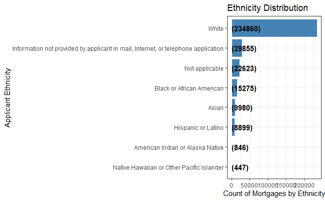

```r
mortgage_by_race_and_ethnicity = hmda_data_pa_df %>% group_by(applicant_race_and_ethnicity) %>%
  summarise(EthnicityCount = n()) %>%
  arrange(desc(EthnicityCount))

graph_by_enthicity(mortgage_by_race_and_ethnicity)
```

# Graph which applicant races and ethnicities have the largest proportion of loans

# in various stages. These include origination status, denied status, etc.

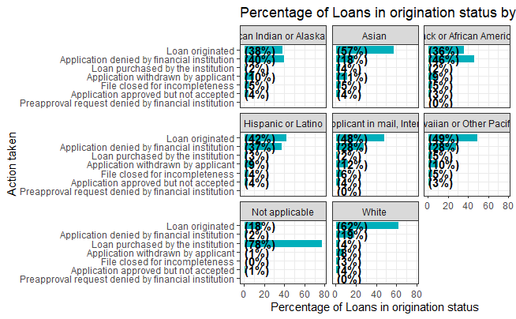

```r
mortgage_status_by_race_and_ethnicity <- hmda_data_pa_df %>% group_by(action_taken_name, applicant_race_and_ethnicity) %>%
  summarise(ActionCount = n()) %>%
  arrange(desc(ActionCount))

mortgage_status_aggregated_by_race_and_ethnicity  = inner_join(mortgage_status_by_race_and_ethnicity, mortgage_by_race_and_ethnicity) %>% mutate(percentage = (ActionCount / EthnicityCount) * 100)
graph_application_race_proportion_of_loans(mortgage_status_aggregated_by_race_and_ethnicity)
```

# Applicant income histograms.

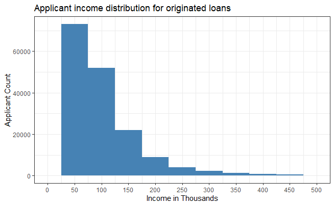

```r
hmda_origination_status_df <- hmda_data_pa_df[hmda_data_pa_df$action_taken == "1", ]
graph_applicant_income_histogram(hmda_origination_status_df, "Applicant income distribution for originated loans")
```

# Graph median income for originated loans.

```r
hmda_origination_status_df <- hmda_data_pa_df[hmda_data_pa_df$action_taken == "1", ]

head(hmda_origination_status_df)
```

|  | as_of_year | respondent_id | agency_name | agency_abbr | agency_code | loan_type_name | loan_type | property_type_name | property_type | loan_purpose_name | loan_purpose | owner_occupancy_name | owner_occupancy | loan_amount_000s | preapproval_name | preapproval | action_taken_name | action_taken | msamd_name | msamd | state_name | state_abbr | state_code | county_name | county_code | census_tract_number | applicant_ethnicity_name | applicant_ethnicity | co_applicant_ethnicity_name | … |
| --- | --- | --- | --- | --- | --- | --- | --- | --- | --- | --- | --- | --- | --- | --- | --- | --- | --- | --- | --- | --- | --- | --- | --- | --- | --- | --- | --- | --- | --- | --- |
| 3 | 2014 | 0000024891 | Office of the Comptroller of the Currency | OCC | 1 | Conventional | 1 | One-to-four family dwelling (other than manufactured housing) | 1 | Home purchase | 1 | Owner-occupied as a principal dwelling | 1 | 132 | Not applicable | 3 | Loan originated | 1 | York, Hanover - PA | 49620 | Pennsylvania | PA | 42 | York County | 133 | 207.10 | Not Hispanic or Latino | 2 | No co-applicant | … |
| 9 | 2014 | 0000057228 | Federal Deposit Insurance Corporation | FDIC | 3 | Conventional | 1 | One-to-four family dwelling (other than manufactured housing) | 1 | Refinancing | 3 | Owner-occupied as a principal dwelling | 1 | 53 | Not applicable | 3 | Loan originated | 1 | Allentown, Bethlehem, Easton - PA, NJ | 10900 | Pennsylvania | PA | 42 | Northampton County | 95 | 162.02 | Not Hispanic or Latino | 2 | No co-applicant | … |
| 11 | 2014 | 0000028178 | Federal Deposit Insurance Corporation | FDIC | 3 | Conventional | 1 | One-to-four family dwelling (other than manufactured housing) | 1 | Home purchase | 1 | Owner-occupied as a principal dwelling | 1 | 108 | Not applicable | 3 | Loan originated | 1 |  | NA | Pennsylvania | PA | 42 | Elk County | 47 | 9511.00 | Not Hispanic or Latino | 2 | No co-applicant | … |
| 12 | 2014 | 0000002099 | National Credit Union Administration | NCUA | 5 | Conventional | 1 | One-to-four family dwelling (other than manufactured housing) | 1 | Refinancing | 3 | Owner-occupied as a principal dwelling | 1 | 265 | Not applicable | 3 | Loan originated | 1 | Montgomery County, Bucks County, Chester County - PA | 33874 | Pennsylvania | PA | 42 | Chester County | 29 | 3044.05 | Not Hispanic or Latino | 2 | Not Hispanic or Latino | … |
| 14 | 2014 | 41-1795868 | Department of Housing and Urban Development | HUD | 7 | Conventional | 1 | One-to-four family dwelling (other than manufactured housing) | 1 | Refinancing | 3 | Owner-occupied as a principal dwelling | 1 | 67 | Not applicable | 3 | Loan originated | 1 | Harrisburg, Carlisle - PA | 25420 | Pennsylvania | PA | 42 | Dauphin County | 43 | 230.00 | Not Hispanic or Latino | 2 | No co-applicant | … |
| 15 | 2014 | 26-4599244 | Department of Housing and Urban Development | HUD | 7 | Conventional | 1 | One-to-four family dwelling (other than manufactured housing) | 1 | Refinancing | 3 | Owner-occupied as a principal dwelling | 1 | 185 | Not applicable | 3 | Loan originated | 1 | Chambersburg, Waynesboro - PA | 16540 | Pennsylvania | PA | 42 | Franklin County | 55 | 125.01 | Not Hispanic or Latino | 2 | No co-applicant | … |

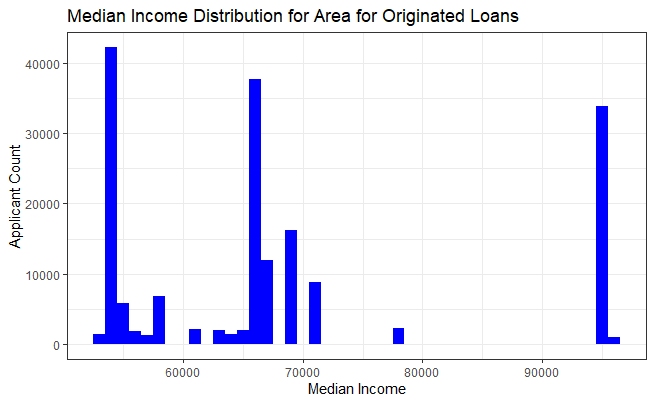

```r
hmda_origination_status_df %>% ggplot(aes(as.numeric(hud_median_family_income))) +
geom_histogram(binwidth = 1000,, fill=c("blue")) + labs(x = "Median Income", y = "Applicant Count", title = "Median Income Distribution for Area for Originated Loans") + theme_bw()
```

## Graph loan distribution by county.

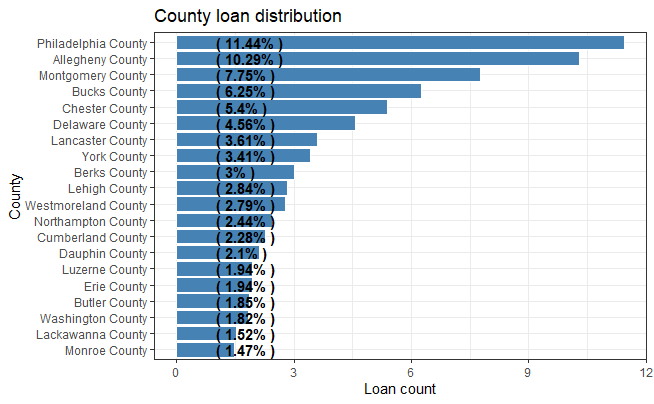

```r
mortgage_distribution_by_counties <- hmda_data_pa_df %>%
  filter(!is.na(county_name)) %>%
  group_by(county_name) %>%
  summarise(CountLoans = n() ) %>%
  mutate(percentage = ( CountLoans / sum(CountLoans) ) * 100 ) %>%
  mutate(county_name = reorder(county_name, percentage)) %>%
  arrange(desc(percentage)) %>%
  head(20)

graph_distribution_by_county(mortgage_distribution_by_counties)
```

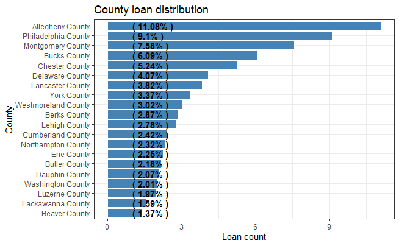

```r
originated_mortgage_distribution_by_counties <- hmda_origination_status_df %>%
  filter(!is.na(county_name)) %>%
  group_by(county_name) %>%
  summarise(CountLoans = n() ) %>%
  mutate(percentage = ( CountLoans / sum(CountLoans) ) *100 ) %>%
  mutate(county_name = reorder(county_name, percentage)) %>%
  arrange(desc(percentage)) %>%
  head(20)

graph_distribution_by_county(originated_mortgage_distribution_by_counties)
```

## Graph home loan application distribution for the top 4 counties in the above

## chart by applicant_race_1

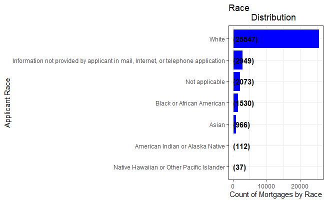

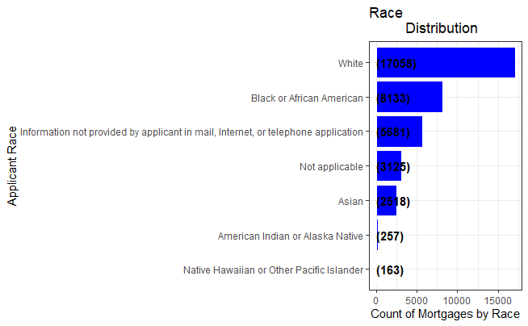

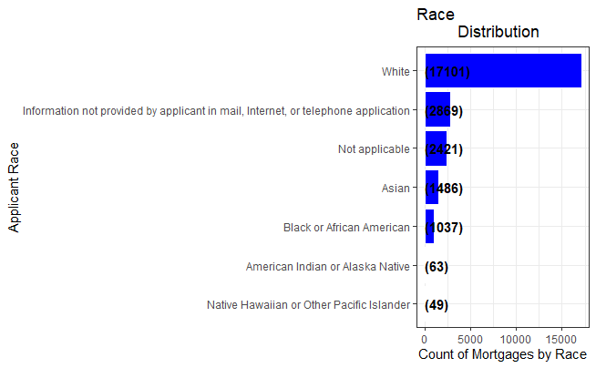

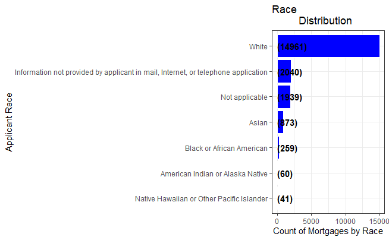

```r
county_names <- c("Allegheny County", "Philadelphia County", "Montgomery County", "Bucks County")

for (county_name in county_names) {

  hmda_data_county_df <- hmda_data_pa_df[hmda_data_pa_df$county_name == county_name, ]

  mortgage_by_race_county <- hmda_data_county_df %>% group_by(applicant_race_name_1) %>%
    summarise(RaceCount = n()) %>% arrange(desc(RaceCount))

  print(graph_mortgage_distribution_by_race1(mortgage_by_race_county))
}
```

## Graph income distribution for Whites and African Americans per county for the

## top 4 counties above.

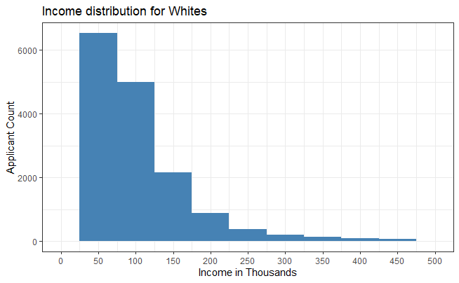

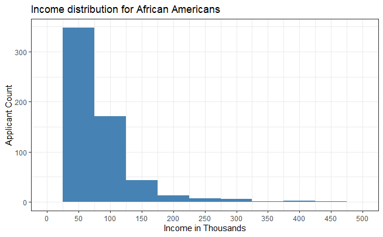

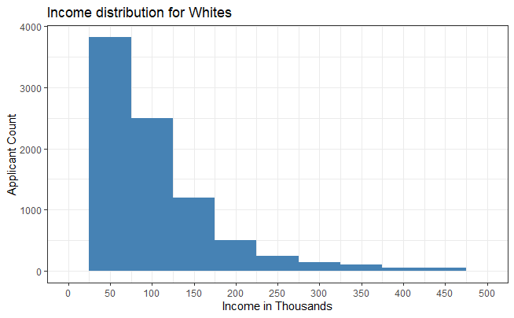

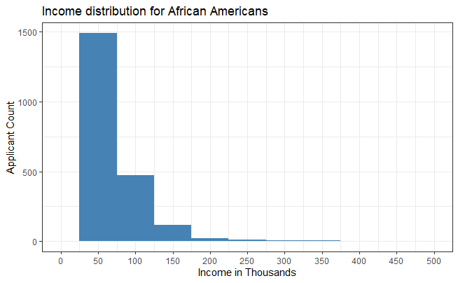

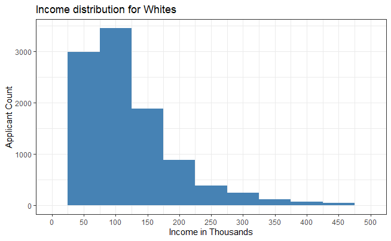

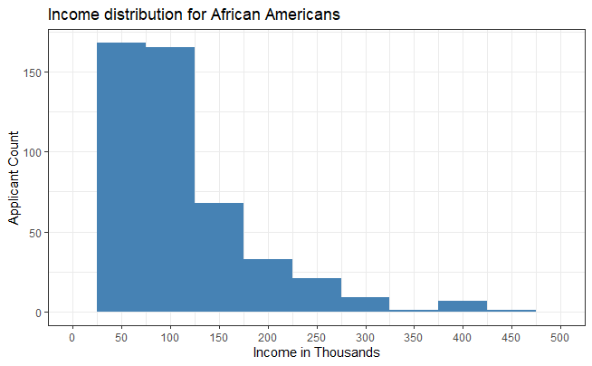

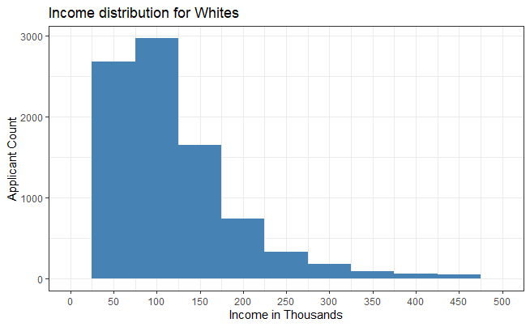

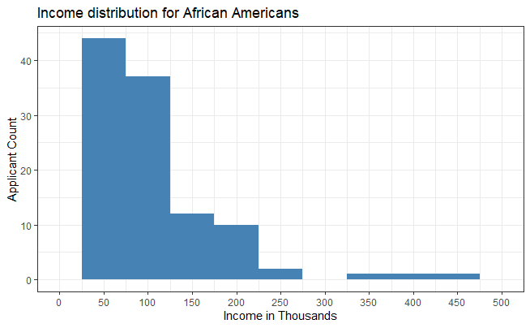

```r
for (county_name in county_names) {
  hmda_origination_status_df_by_county_white <- hmda_data_pa_df[hmda_data_pa_df$action_taken == "1" & hmda_data_pa_df$county_name == county_name & hmda_data_pa_df$applicant_race_name_1 == "White", ]
  print(graph_applicant_income_histogram(hmda_origination_status_df_by_county_white, "Income distribution for Whites"))

  hmda_origination_status_df_by_county_african_american <- hmda_data_pa_df[hmda_data_pa_df$action_taken == "1" & hmda_data_pa_df$county_name == county_name & hmda_data_pa_df$applicant_race_name_1 == "Black or African American", ]
  print(graph_applicant_income_histogram(hmda_origination_status_df_by_county_african_american, "Income distribution for African Americans"))
}
```

## Graph home loan application distribution for the top 4 counties in the above

## chart by applicant_race_and_ethnicity

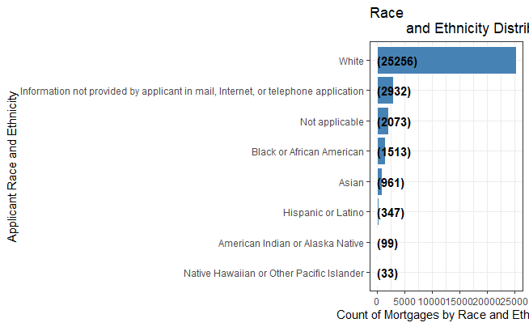

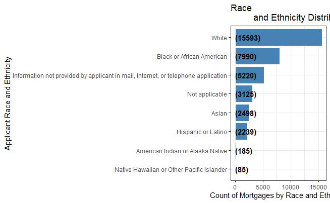

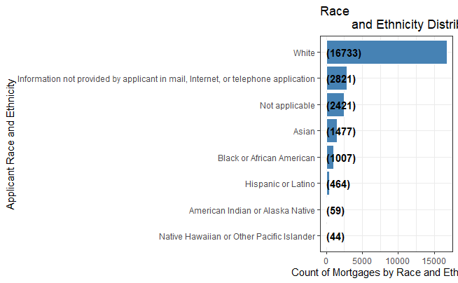

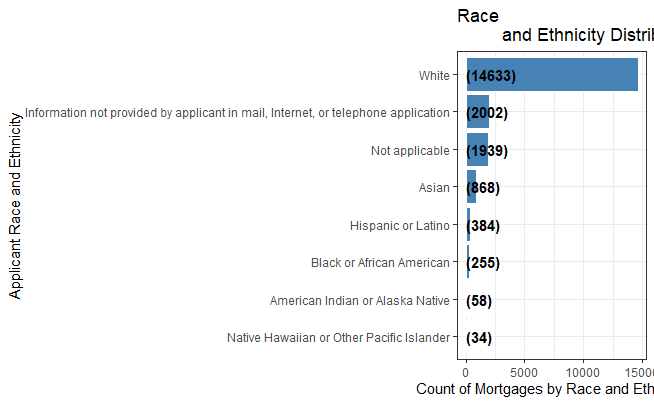

```r
county_names <- c("Allegheny County", "Philadelphia County", "Montgomery County", "Bucks County")

for (county_name in county_names) {

  hmda_data_county_df <- hmda_data_pa_df[hmda_data_pa_df$county_name == county_name, ]

  mortgage_by_race_county <- hmda_data_county_df %>% group_by(applicant_race_and_ethnicity) %>%
    summarise(RaceCount = n()) %>% arrange(desc(RaceCount))

  print(graph_mortgage_distribution_by_race_and_ethnicity(mortgage_by_race_county))
}
```

# Graph which communities have the largest proportion of loans in various stages.

# for the top 4 counties listed above.

# These include origination status, denied status, etc.

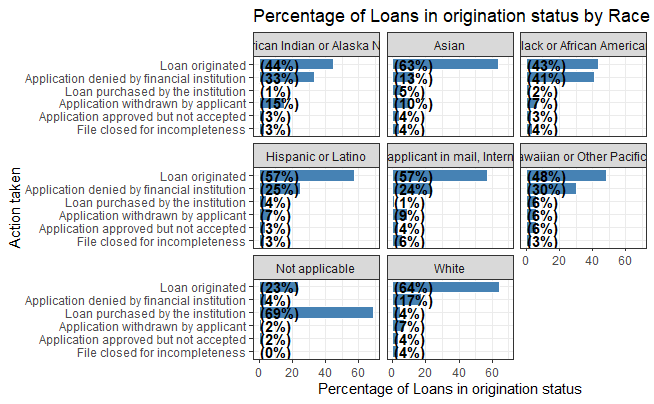

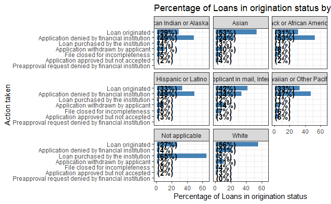

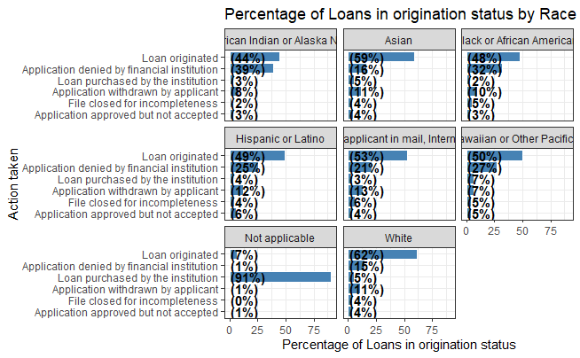

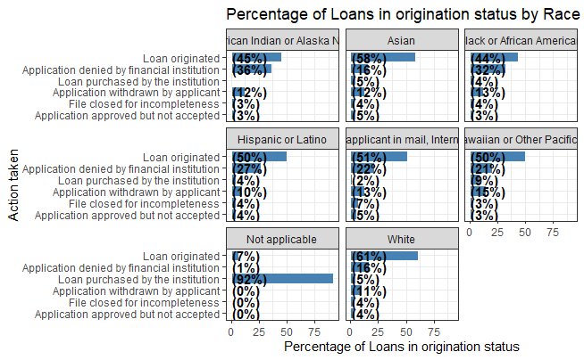

```r
for (county_name in county_names) {

  hmda_data_county_df <- hmda_data_pa_df[hmda_data_pa_df$county_name == county_name, ]

  mortgage_by_race1_county <- hmda_data_county_df %>% group_by(applicant_race_and_ethnicity) %>%
    summarise(RaceCount = n()) %>% arrange(desc(RaceCount))

  mortgage_status_by_race1_by_county <- hmda_data_county_df %>% group_by(action_taken_name, applicant_race_and_ethnicity) %>%
    summarise(ActionCount = n()) %>%
    arrange(desc(ActionCount))

  mortgage_status_aggregated_by_race1_by_county  = inner_join(mortgage_status_by_race1_by_county, mortgage_by_race1_county) %>% mutate(percentage = (ActionCount / RaceCount) * 100)

  print(graph_application_race_and_ethnicity_proportion_of_loans(mortgage_status_aggregated_by_race1_by_county))
}
```

# Visualize missing variables and impute as needed.

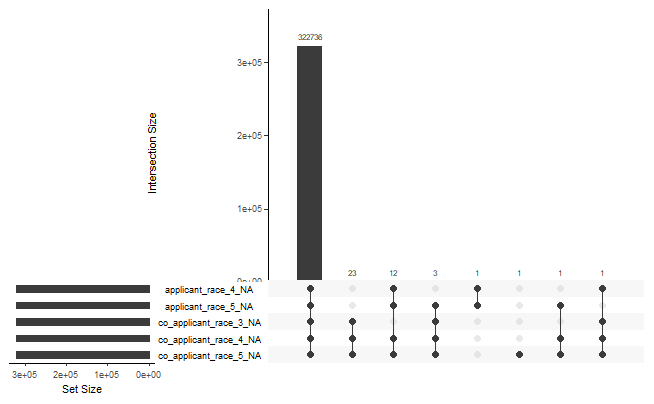

```r
library(mice)
library(naniar)

# https://cran.r-project.org/web/packages/naniar/vignettes/naniar-visualisation.html
gg_miss_upset(hmda_data_pa_df)
```

```r
# https://www.rdocumentation.org/packages/mice/versions/3.8.0/topics/mice.impute.cart
hmda_data_pa_df_imputed <- mice(hmda_data_pa_df, m=1, maxit=2, meth='cart',seed=500)
```

```
Number of logged events: 63
```

```r
hmda_data_pa_df_imputed <- mice::complete(hmda_data_pa_df_imputed)
```

## More analysis on the imputed dataset.

```r
summary(hmda_data_pa_df_imputed)
```

```
   as_of_year   respondent_id      agency_name        agency_abbr
 Min.   :2014   Length:322785      Length:322785      Length:322785
 1st Qu.:2014   Class :character   Class :character   Class :character
 Median :2014   Mode  :character   Mode  :character   Mode  :character
 Mean   :2014
 3rd Qu.:2014
 Max.   :2014

  agency_code    loan_type_name       loan_type property_type_name
 Min.   :1.000   Length:322785      Min.   :1   Length:322785
 1st Qu.:5.000   Class :character   1st Qu.:1   Class :character
 Median :7.000   Mode  :character   Median :1   Mode  :character
 Mean   :6.348                      Mean   :1
 3rd Qu.:9.000                      3rd Qu.:1
 Max.   :9.000                      Max.   :1

 property_type   loan_purpose_name   loan_purpose   owner_occupancy_name
 Min.   :1.000   Length:322785      Min.   :1.000   Length:322785
 1st Qu.:1.000   Class :character   1st Qu.:1.000   Class :character
 Median :1.000   Mode  :character   Median :2.000   Mode  :character
 Mean   :1.032                      Mean   :2.075
 3rd Qu.:1.000                      3rd Qu.:3.000
 Max.   :3.000                      Max.   :3.000

 owner_occupancy loan_amount_000s  preapproval_name    preapproval
 Min.   :1.00    Min.   :    1.0   Length:322785      Min.   :1.000
 1st Qu.:1.00    1st Qu.:   60.0   Class :character   1st Qu.:3.000
 Median :1.00    Median :  120.0   Mode  :character   Median :3.000
 Mean   :1.12    Mean   :  168.2                      Mean   :2.879
 3rd Qu.:1.00    3rd Qu.:  206.0                      3rd Qu.:3.000
 Max.   :3.00    Max.   :99999.0                      Max.   :3.000

 action_taken_name   action_taken    msamd_name            msamd
 Length:322785      Min.   :1.000   Length:322785      Min.   :10900
 Class :character   1st Qu.:1.000   Class :character   1st Qu.:33874
 Mode  :character   Median :1.000   Mode  :character   Median :37964
                    Mean   :2.268                      Mean   :33841
                    3rd Qu.:3.000                      3rd Qu.:38300
                    Max.   :7.000                      Max.   :49660

```

[output cut: 133 more lines]

```
 3rd Qu.:127.01        3rd Qu.:1795
 Max.   :397.45        Max.   :3262

 number_of_1_to_4_family_units application_date_indicator
 Min.   :   8                  Min.   :0.0000
 1st Qu.:1340                  1st Qu.:0.0000
 Median :1758                  Median :0.0000
 Mean   :1823                  Mean   :0.1732
 3rd Qu.:2289                  3rd Qu.:0.0000
 Max.   :4173                  Max.   :2.0000

 applicant_race_and_ethnicity co_applicant_race_and_ethnicity
 Length:322785                Length:322785
 Class :character             Class :character
 Mode  :character             Mode  :character
```

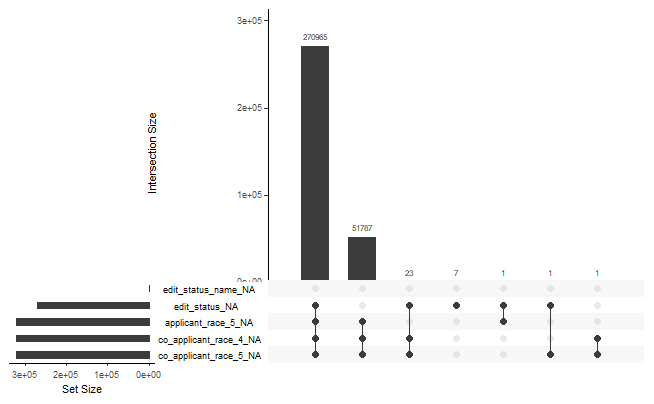

```r
gg_miss_upset(hmda_data_pa_df_imputed)
```

# Additional analysis on the hmda dataset. correlation matrix, plots, etc.

```r
# https://stackoverflow.com/questions/20637360/convert-all-data-frame-character-columns-to-factors
hmda_data_pa_df$loan_to_income_ratio <- hmda_data_pa_df$loan_amount_000s / hmda_data_pa_df$applicant_income_000s

hmda_data_pa_df[sapply(hmda_data_pa_df, is.character)] <- lapply(hmda_data_pa_df[sapply(hmda_data_pa_df, is.character)],
                                       as.factor)

hmda_data_pa_df_for_correlation <- as.data.frame(lapply(hmda_data_pa_df, as.integer))

#head(hmda_data_pa_df_for_correlation[, c("applicant_income_000s", "loan_amount_000s")])

head(hmda_data_pa_df_for_correlation)
```

|  | as_of_year | respondent_id | agency_name | agency_abbr | agency_code | loan_type_name | loan_type | property_type_name | property_type | loan_purpose_name | loan_purpose | owner_occupancy_name | owner_occupancy | loan_amount_000s | preapproval_name | preapproval | action_taken_name | action_taken | msamd_name | msamd | state_name | state_abbr | state_code | county_name | county_code | census_tract_number | applicant_ethnicity_name | applicant_ethnicity | co_applicant_ethnicity_name | … |
| --- | --- | --- | --- | --- | --- | --- | --- | --- | --- | --- | --- | --- | --- | --- | --- | --- | --- | --- | --- | --- | --- | --- | --- | --- | --- | --- | --- | --- | --- | --- |
| 1 | 2014 | 931 | 2 | 4 | 7 | 1 | 1 | 3 | 1 | 3 | 3 | 3 | 1 | 81 | 1 | 3 | 2 | 3 | 1 | NA | 1 | 1 | 42 | 38 | 73 | 111 | 4 | 2 | 3 | … |
| 2 | 2014 | 378 | 6 | 6 | 1 | 1 | 1 | 3 | 1 | 2 | 1 | 3 | 1 | 132 | 1 | 3 | 5 | 1 | 21 | 49620 | 1 | 1 | 42 | 68 | 133 | 207 | 4 | 2 | 3 | … |
| 3 | 2014 | 988 | 2 | 4 | 7 | 1 | 1 | 3 | 1 | 2 | 1 | 3 | 1 | 158 | 2 | 2 | 2 | 3 | 11 | 29540 | 1 | 1 | 42 | 37 | 71 | 117 | 4 | 2 | 3 | … |
| 4 | 2014 | 931 | 2 | 4 | 7 | 1 | 1 | 3 | 1 | 3 | 3 | 3 | 1 | 236 | 1 | 3 | 3 | 4 | 13 | 33874 | 1 | 1 | 42 | 10 | 17 | 1016 | 4 | 2 | 3 | … |
| 5 | 2014 | 480 | 3 | 2 | 3 | 1 | 1 | 3 | 1 | 3 | 3 | 3 | 1 | 53 | 1 | 3 | 5 | 1 | 2 | 10900 | 1 | 1 | 42 | 49 | 95 | 162 | 4 | 2 | 3 | … |
| 6 | 2014 | 931 | 2 | 4 | 7 | 1 | 1 | 3 | 1 | 2 | 1 | 2 | 2 | 150 | 1 | 3 | 6 | 6 | 13 | 33874 | 1 | 1 | 42 | 10 | 17 | 1055 | 3 | 4 | 4 | … |

```
the standard deviation is zero
```

|  | Var1 | Var2 | Freq |
| --- | --- | --- | --- |
| 984 | owner_occupancy_name | owner_occupancy | -1.0000000 |
| 1230 | preapproval_name | preapproval | -1.0000000 |
| 4323 | co_applicant_ethnicity | co_applicant_sex | 0.9784376 |
| 3351 | co_applicant_ethnicity | co_applicant_race_1 | 0.9596442 |
| 6440 | co_applicant_race_name_1 | co_applicant_race_and_ethnicity | 0.9471551 |
| 4335 | co_applicant_race_1 | co_applicant_sex | 0.9456767 |
| 6349 | applicant_race_name_1 | applicant_race_and_ethnicity | 0.9355418 |
| 4242 | co_applicant_ethnicity | co_applicant_sex_name | 0.8782195 |
| 3935 | co_applicant_race_name_4 | co_applicant_race_name_5 | 0.8735859 |
| 327 | agency_name | agency_code | -0.8629403 |

[output cut: 30 more lines]

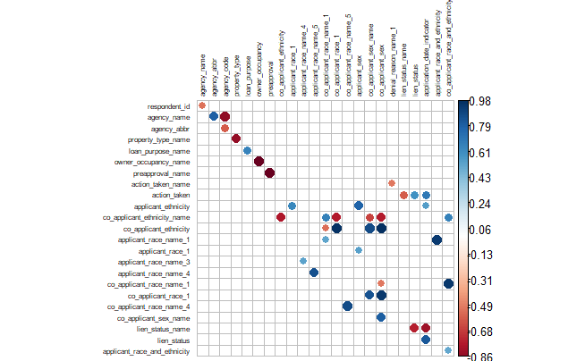

```r
corr_simple(hmda_data_pa_df_for_correlation)
```

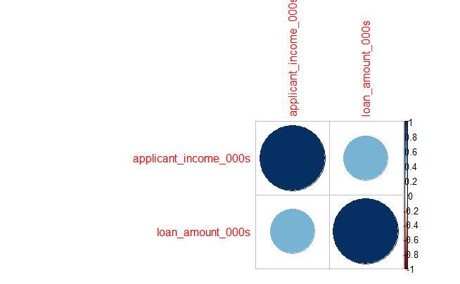

```r
corrplot(cor(hmda_data_pa_df_for_correlation[, c("applicant_income_000s", "loan_amount_000s")], use = "na.or.complete"))
```

# Additional analysis on the hmda imputed dataset. correlation plots, etc.

```r
# hmda_data_pa_df_imputed <- hmda_data_pa_df;
# https://stackoverflow.com/questions/20637360/convert-all-data-frame-character-columns-to-factors
hmda_data_pa_df_imputed$loan_to_income_ratio <- hmda_data_pa_df_imputed$loan_amount_000s / hmda_data_pa_df_imputed$applicant_income_000s

hmda_data_pa_df_imputed[sapply(hmda_data_pa_df_imputed, is.character)] <- lapply(hmda_data_pa_df_imputed[sapply(hmda_data_pa_df_imputed, is.character)],
                                       as.factor)

hmda_data_pa_df_imputed_for_correlation <- as.data.frame(lapply(hmda_data_pa_df_imputed, as.integer))

head(hmda_data_pa_df_imputed_for_correlation[, c("applicant_income_000s", "loan_amount_000s")])
```

|  | applicant_income_000s | loan_amount_000s |
| --- | --- | --- |
| 1 | 30 | 81 |
| 2 | 49 | 132 |
| 3 | 76 | 158 |
| 4 | 105 | 236 |
| 5 | 53 | 53 |
| 6 | 167 | 150 |

```
the standard deviation is zero
```

|  | Var1 | Var2 | Freq |
| --- | --- | --- | --- |
| 984 | owner_occupancy_name | owner_occupancy | -1.0000000 |
| 1230 | preapproval_name | preapproval | -1.0000000 |
| 1968 | county_name | county_code | 0.9978767 |
| 4323 | co_applicant_ethnicity | co_applicant_sex | 0.9784376 |
| 3351 | co_applicant_ethnicity | co_applicant_race_1 | 0.9596442 |
| 6440 | co_applicant_race_name_1 | co_applicant_race_and_ethnicity | 0.9471551 |
| 4335 | co_applicant_race_1 | co_applicant_sex | 0.9456767 |
| 6349 | applicant_race_name_1 | applicant_race_and_ethnicity | 0.9355418 |
| 3033 | applicant_race_3 | applicant_race_4 | 0.8982638 |
| 4242 | co_applicant_ethnicity | co_applicant_sex_name | 0.8782195 |

[output cut: 40 more lines]

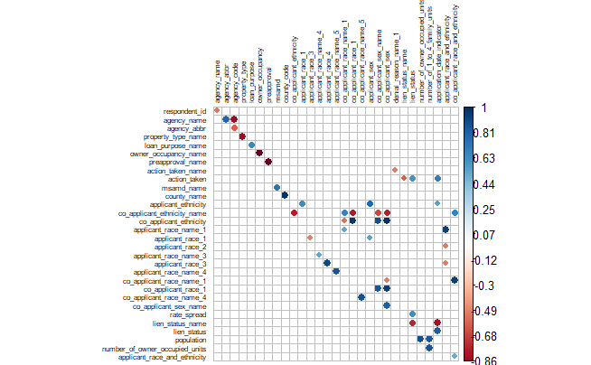

```r
corr_simple(hmda_data_pa_df_imputed_for_correlation)
```

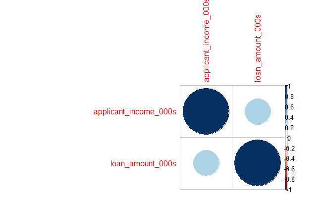

```r
corrplot(cor(hmda_data_pa_df_imputed_for_correlation[, c("applicant_income_000s", "loan_amount_000s")], use = "na.or.complete"))
```

# Preparation for inital model. Selecting columns.

```r
data_frame_for_model <- function(input_df) {
  # Added based on intuition. Please update as needed.
  # msamd -> Metropolitan Statistical Area Division code.
  # https://cfpb.github.io/api/hmda/fields.html
  initial_columns_for_model <- c("applicant_race_and_ethnicity", "applicant_income_000s", "co_applicant_race_and_ethnicity", "co_applicant_sex", "county_code", "hoepa_status", "lien_status", "msamd", "owner_occupancy", "preapproval", "property_type", "purchaser_type", "loan_amount_000s", "county_name", "applicant_sex", "hud_median_family_income", "tract_to_msamd_income", "loan_to_income_ratio", "agency_code", "minority_population")

  # https://stackoverflow.com/questions/10085806/extracting-specific-columns-from-a-data-frame
  df_for_model <- input_df %>% select(initial_columns_for_model)
  df_for_model$loan_granted <- input_df$action_taken == 1 | input_df$action_taken == 6
  return (df_for_model)
}
```

# Create dataframe based on selected column list from the source dataframe.

```r
hmda_data_pa_df_imputed_for_model <- data_frame_for_model(hmda_data_pa_df_imputed)
```

```r
unique(hmda_data_pa_df_imputed$co_applicant_race_and_ethnicity)
```

```
[1] No co-applicant
[2] Not applicable
[3] White
[4] Information not provided by applicant in mail, Internet, or telephone application
[5] Black or African American
[6] Hispanic or Latino
[7] Asian
[8] Native Hawaiian or Other Pacific Islander
[9] American Indian or Alaska Native
9 Levels: American Indian or Alaska Native ... White
```

```r
hmda_data_pa_df_imputed_for_model$co_applicant_present <- NA

hmda_data_pa_df_imputed_for_model$co_applicant_present <- ifelse( hmda_data_pa_df_imputed_for_model$co_applicant_race_and_ethnicity == "White" | hmda_data_pa_df_imputed_for_model$co_applicant_race_and_ethnicity == "Black or African American" | hmda_data_pa_df_imputed_for_model$co_applicant_race_and_ethnicity == "Hispanic or Latino" | hmda_data_pa_df_imputed_for_model$co_applicant_race_and_ethnicity == "Asian" | hmda_data_pa_df_imputed_for_model$co_applicant_race_and_ethnicity == "Native Hawaiian or Other Pacific Islander" | hmda_data_pa_df_imputed_for_model$co_applicant_race_and_ethnicity == "American Indian or Alaska Native", 1, 0)

#hmda_data_pa_df_imputed_for_model$co_applicant_present <- as.factor(hmda_data_pa_df_imputed_for_model$co_applicant_present)

nrow(hmda_data_pa_df_imputed_for_model)
```

```
[1] 322785
```

```r
sum(hmda_data_pa_df_imputed_for_model$co_applicant_present == 1)
```

```
[1] 129553
```

```r
sum(hmda_data_pa_df_imputed_for_model$co_applicant_present == 0)
```

```
[1] 193232
```

```r
hmda_data_pa_df_imputed_for_model$applicant_race_and_ethnicity <- as.factor(hmda_data_pa_df_imputed_for_model$applicant_race_and_ethnicity)

hmda_data_pa_df_imputed_for_model$co_applicant_sex <- as.factor(hmda_data_pa_df_imputed_for_model$co_applicant_sex)

hmda_data_pa_df_imputed_for_model$co_applicant_present <- as.factor(hmda_data_pa_df_imputed_for_model$co_applicant_present)

hmda_data_pa_df_imputed_for_model$county_code <- hmda_data_pa_df_imputed_for_model$county_code

hmda_data_pa_df_imputed_for_model$hoepa_status <- as.factor(hmda_data_pa_df_imputed_for_model$hoepa_status)

hmda_data_pa_df_imputed_for_model$lien_status <- as.factor(hmda_data_pa_df_imputed_for_model$lien_status)

hmda_data_pa_df_imputed_for_model$preapproval <- as.factor(hmda_data_pa_df_imputed_for_model$preapproval)

hmda_data_pa_df_imputed_for_model$property_type <- as.factor(hmda_data_pa_df_imputed_for_model$property_type)

hmda_data_pa_df_imputed_for_model$purchaser_type <- as.factor(hmda_data_pa_df_imputed_for_model$purchaser_type)

hmda_data_pa_df_imputed_for_model$applicant_sex <- as.factor(hmda_data_pa_df_imputed_for_model$applicant_sex)

hmda_data_pa_df_imputed_for_model$county_code <- as.factor(hmda_data_pa_df_imputed_for_model$county_code)

hmda_data_pa_df_imputed_for_model$county_name <- as.factor(hmda_data_pa_df_imputed_for_model$county_name)

hmda_data_pa_df_imputed_for_model$agency_code <- as.factor(hmda_data_pa_df_imputed_for_model$agency_code)

hmda_data_pa_df_imputed_for_model$owner_occupancy <- as.factor(hmda_data_pa_df_imputed_for_model$owner_occupancy)

head(hmda_data_pa_df_imputed_for_model)
```

|  | applicant_race_and_ethnicity | applicant_income_000s | co_applicant_race_and_ethnicity | co_applicant_sex | county_code | hoepa_status | lien_status | msamd | owner_occupancy | preapproval | property_type | purchaser_type | loan_amount_000s | county_name | applicant_sex | hud_median_family_income | tract_to_msamd_income | loan_to_income_ratio | agency_code | minority_population | loan_granted | co_applicant_present |
| --- | --- | --- | --- | --- | --- | --- | --- | --- | --- | --- | --- | --- | --- | --- | --- | --- | --- | --- | --- | --- | --- | --- |
| 1 | White | 30 | No co-applicant | 5 | 73 | 2 | 1 | 27780 | 1 | 3 | 1 | 0 | 81 | Lawrence County | 1 | 54100 | 96.77 | 2.7000000 | 7 | 2.53 | FALSE | 0 |
| 2 | White | 49 | No co-applicant | 5 | 133 | 2 | 1 | 49620 | 1 | 3 | 1 | 3 | 132 | York County | 1 | 68700 | 93.10 | 2.6938776 | 1 | 10.74 | TRUE | 0 |
| 3 | White | 76 | No co-applicant | 5 | 71 | 2 | 1 | 29540 | 1 | 2 | 1 | 0 | 158 | Lancaster County | 2 | 67200 | 161.91 | 2.0789474 | 7 | 14.19 | FALSE | 0 |
| 4 | Black or African American | 105 | No co-applicant | 5 | 17 | 2 | 1 | 33874 | 1 | 3 | 1 | 0 | 236 | Bucks County | 2 | 95400 | 69.79 | 2.2476190 | 7 | 15.31 | FALSE | 0 |
| 5 | White | 53 | No co-applicant | 5 | 95 | 2 | 1 | 10900 | 1 | 3 | 1 | 0 | 53 | Northampton County | 2 | 68800 | 102.17 | 1.0000000 | 3 | 6.07 | TRUE | 0 |
| 6 | Not applicable | 167 | Not applicable | 4 | 17 | 2 | 4 | 33874 | 2 | 3 | 1 | 1 | 150 | Bucks County | 4 | 95400 | 107.64 | 0.8982036 | 7 | 18.60 | TRUE | 0 |

```r
hmda_data_pa_df_imputed_for_model$log_loan_amount_000s <- log(hmda_data_pa_df_imputed_for_model$loan_amount_000s)

hmda_data_pa_df_imputed_for_model$log_applicant_income_000s <- log(hmda_data_pa_df_imputed_for_model$applicant_income_000s)
```

# Train test split. Stratified sampling

```r
train_test_split <- function(input_df, train_proportion = 0.8) {
  library(caret)

  # https://stackoverflow.com/questions/20776887/stratified-splitting-the-data
  train.index <- createDataPartition(y = input_df$loan_granted, p = train_proportion, list = FALSE)

  train <- input_df[train.index, ]
  test <-  input_df[-train.index, ]

  train$loan_granted <- as.factor(train$loan_granted)
  test$loan_granted <- as.factor(test$loan_granted)

  val_list <- list(train, test)
  return (val_list)
}
```

# Generate train/test split.

```r
sum(hmda_data_pa_df_imputed_for_model$loan_granted == TRUE)
```

```
[1] 207202
```

```r
sum(hmda_data_pa_df_imputed_for_model$loan_granted == FALSE)
```

```
[1] 115583
```

```r
nrow(hmda_data_pa_df_imputed)
```

```
[1] 322785
```

```r
split_dfs <- train_test_split(hmda_data_pa_df_imputed_for_model[, -which(names(hmda_data_pa_df_imputed_for_model) %in% c("co_applicant_race_and_ethnicity", "county_name"))])
train <- split_dfs[[1]]
test <- split_dfs[[2]]

head(train)
```

|  | applicant_race_and_ethnicity | applicant_income_000s | co_applicant_sex | county_code | hoepa_status | lien_status | msamd | owner_occupancy | preapproval | property_type | purchaser_type | loan_amount_000s | applicant_sex | hud_median_family_income | tract_to_msamd_income | loan_to_income_ratio | agency_code | minority_population | loan_granted | co_applicant_present | log_loan_amount_000s | log_applicant_income_000s |
| --- | --- | --- | --- | --- | --- | --- | --- | --- | --- | --- | --- | --- | --- | --- | --- | --- | --- | --- | --- | --- | --- | --- |
| 2 | White | 49 | 5 | 133 | 2 | 1 | 49620 | 1 | 3 | 1 | 3 | 132 | 1 | 68700 | 93.10 | 2.6938776 | 1 | 10.74 | TRUE | 0 | 4.882802 | 3.891820 |
| 3 | White | 76 | 5 | 71 | 2 | 1 | 29540 | 1 | 2 | 1 | 0 | 158 | 2 | 67200 | 161.91 | 2.0789474 | 7 | 14.19 | FALSE | 0 | 5.062595 | 4.330733 |
| 4 | Black or African American | 105 | 5 | 17 | 2 | 1 | 33874 | 1 | 3 | 1 | 0 | 236 | 2 | 95400 | 69.79 | 2.2476190 | 7 | 15.31 | FALSE | 0 | 5.463832 | 4.653960 |
| 5 | White | 53 | 5 | 95 | 2 | 1 | 10900 | 1 | 3 | 1 | 0 | 53 | 2 | 68800 | 102.17 | 1.0000000 | 3 | 6.07 | TRUE | 0 | 3.970292 | 3.970292 |
| 6 | Not applicable | 167 | 4 | 17 | 2 | 4 | 33874 | 2 | 3 | 1 | 1 | 150 | 4 | 95400 | 107.64 | 0.8982036 | 7 | 18.60 | TRUE | 0 | 5.010635 | 5.117994 |
| 7 | White | 36 | 5 | 47 | 2 | 1 | 38300 | 1 | 3 | 1 | 0 | 108 | 1 | 54100 | 106.73 | 3.0000000 | 3 | 1.94 | TRUE | 0 | 4.682131 | 3.583519 |

```r
unique(train$co_applicant_present)
```

```
[1] 0 1
Levels: 0 1
```

# Analysis on the train and test split datasets.

```r
writeLines("")
```

```r
writeLines("Possible values for applicant_race_and_ethnicity")
```

```
Possible values for applicant_race_and_ethnicity
```

```r
levels(hmda_data_pa_df_imputed_for_model$applicant_race_and_ethnicity)
```

```
[1] "American Indian or Alaska Native"
[2] "Asian"
[3] "Black or African American"
[4] "Hispanic or Latino"
[5] "Information not provided by applicant in mail, Internet, or telephone application"
[6] "Native Hawaiian or Other Pacific Islander"
[7] "Not applicable"
[8] "White"
```

```r
writeLines("")
```

```r
writeLines("[train df]. Race and ethnicity numbers for whites and African Americans")
```

```
[train df]. Race and ethnicity numbers for whites and African Americans
```

```r
nrow(train)
```

```
[1] 258229
```

```r
sum(train$applicant_race_and_ethnicity == "White")
```

```
[1] 187990
```

```r
sum(train$applicant_race_and_ethnicity == "Black or African American")
```

```
[1] 12157
```

```r
writeLines("")
```

```r
writeLines("Generating upsampled training dataframe based on race and ethnicity")
```

```
Generating upsampled training dataframe based on race and ethnicity
```

```r
set.seed(1000)

up_train <- upSample(x = train, y = train$applicant_race_and_ethnicity)

writeLines("")
```

```r
writeLines("[Upsampled train df]. Race and ethnicity numbers for whites and African Americans")
```

```
[Upsampled train df]. Race and ethnicity numbers for whites and African Americans
```

```r
sum(as.character(up_train$applicant_race_and_ethnicity) == "White")
```

```
[1] 187990
```

```r
sum(as.character(up_train$applicant_race_and_ethnicity) == "Black or African American")
```

```
[1] 187990
```

```r
nrow(up_train)
```

```
[1] 1503920
```

```r
writeLines("")
```

```r
writeLines("[test df].Race and ethnicity numbers for whites and African Americans")
```

```
[test df].Race and ethnicity numbers for whites and African Americans
```

```r
nrow(test)
```

```
[1] 64556
```

```r
sum(test$applicant_race_and_ethnicity == "White")
```

```
[1] 46870
```

```r
sum(test$applicant_race_and_ethnicity == "Black or African American")
```

```
[1] 3118
```

# Model 1 without loan to income ratio.

```r
# Initial model. Predictors selected are based on intuition.
# Please update this list as needed.
#model <- glm(loan_granted~applicant_race_and_ethnicity+applicant_income_000s+co_applicant_race_and_ethnicity+co_applicant_sex+hoepa_status+lien_status+owner_occupancy+preapproval+property_type+loan_amount_000s+msamd+applicant_sex+county_code+hud_median_family_income+tract_to_msamd_income+co_applicant_present, family = binomial(link='logit'), data=train)

model <- glm(loan_granted~applicant_race_and_ethnicity+applicant_income_000s+hoepa_status+lien_status+owner_occupancy+preapproval+property_type+loan_amount_000s+msamd+applicant_sex+county_code+hud_median_family_income+tract_to_msamd_income+co_applicant_present+agency_code+minority_population, family = binomial(link='logit'), data=train)


writeLines("Summary for model is as below")
```

```
Summary for model is as below
```

```r
writeLines("")
```

```r
summary(model)
```

```
Call:
glm(formula = loan_granted ~ applicant_race_and_ethnicity + applicant_income_000s +
    hoepa_status + lien_status + owner_occupancy + preapproval +
    property_type + loan_amount_000s + msamd + applicant_sex +
    county_code + hud_median_family_income + tract_to_msamd_income +
    co_applicant_present + agency_code + minority_population,
    family = binomial(link = "logit"), data = train)

Deviance Residuals:
    Min       1Q   Median       3Q      Max
-2.7068  -1.1704   0.6893   0.9532   2.2680

Coefficients:
                                                                                                                Estimate
(Intercept)                                                                                                    1.679e+01
applicant_race_and_ethnicityAsian                                                                              6.551e-01
applicant_race_and_ethnicityBlack or African American                                                          2.191e-01
applicant_race_and_ethnicityHispanic or Latino                                                                 2.824e-01
applicant_race_and_ethnicityInformation not provided by applicant in mail, Internet, or telephone application  3.309e-01
applicant_race_and_ethnicityNative Hawaiian or Other Pacific Islander                                          4.854e-01
applicant_race_and_ethnicityNot applicable                                                                    -2.247e-01
applicant_race_and_ethnicityWhite                                                                              7.820e-01
applicant_income_000s                                                                                          2.150e-04
hoepa_status2                                                                                                 -1.711e+01
lien_status2                                                                                                  -2.271e-01
lien_status3                                                                                                  -4.598e-01
lien_status4                                                                                                   1.677e+01
owner_occupancy2                                                                                              -3.543e-02
owner_occupancy3                                                                                               2.896e-02
preapproval2                                                                                                  -3.830e-02
preapproval3                                                                                                  -8.366e-01
property_type2                                                                                                -9.952e-01
property_type3                                                                                                -1.266e-01
loan_amount_000s                                                                                              -9.507e-06
msamd                                                                                                         -1.371e-05
applicant_sex2                                                                                                -5.253e-02
applicant_sex3                                                                                                 2.096e-02
applicant_sex4                                                                                                 1.855e+00
county_code3                                                                                                   4.549e-01
county_code5                                                                                                   2.195e-01
```

[output cut: 468 more lines]

```
agency_code3                                                                                                  ***
agency_code5                                                                                                  **
agency_code7                                                                                                  ***
agency_code9                                                                                                  ***
minority_population                                                                                           ***
---
Signif. codes:  0 ‘***’ 0.001 ‘**’ 0.01 ‘*’ 0.05 ‘.’ 0.1 ‘ ’ 1

(Dispersion parameter for binomial family taken to be 1)

    Null deviance: 336889  on 258228  degrees of freedom
Residual deviance: 296438  on 258130  degrees of freedom
AIC: 296636

Number of Fisher Scoring iterations: 16
```

```r
writeLines("Anova for model is as below")
```

```
Anova for model is as below
```

```r
writeLines("")
```

```r
anova(model)
```

```
Analysis of Deviance Table

Model: binomial, link: logit

Response: loan_granted

Terms added sequentially (first to last)

                             Df Deviance Resid. Df Resid. Dev
NULL                                        258228     336889
applicant_race_and_ethnicity  7  17564.3    258221     319325
applicant_income_000s         1    363.5    258220     318961
hoepa_status                  1     32.8    258219     318928
lien_status                   3  11729.0    258216     307199
owner_occupancy               2     88.7    258214     307111
preapproval                   2   2809.2    258212     304301
property_type                 2    995.8    258210     303306
loan_amount_000s              1      8.5    258209     303297
msamd                         1     16.2    258208     303281
applicant_sex                 3    210.3    258205     303071
county_code                  66   1568.7    258139     301502
hud_median_family_income      1      6.4    258138     301496
tract_to_msamd_income         1    627.7    258137     300868
co_applicant_present          1    981.5    258136     299886
agency_code                   5   3196.9    258131     296689
minority_population           1    251.1    258130     296438
```